# 用Python实现校园通知更新提醒

## 简介

学校总是有很多的通知，分别在不同的网站上发布，如学校主页、教务处、图书馆以及学院的网站等，一个个查看过于麻烦，利用python写一个中央财经大学的通知爬虫，设计一个本校消息的自动通知程序

## 实现

- 使用requests库获取到目标url(各个网站的’更多通知’页)的源代码，然后利用Python的BeautifulSoup库进行信息的筛选，提取到通知相关信息后，与当前时间相对比，如果为今天则加入一个OrderedDict中，保存为新通知。
- 若检测到有新的通知，则利用smtplib库向指定邮箱发送提醒信息。

## 第一步 基本爬虫

```python
import requests
import re
import time
from bs4 import BeautifulSoup
from collections import OrderedDict

def get_news1():
    """
    获取教务处网址上的page页的新闻，返回一个通知字典
    """
    newsData = OrderedDict()
    href = "http://jwc.cufe.edu.cn/tzgg.htm"
    html = requests.get(href)
    # Parsing html
    soup = BeautifulSoup(html.content, 'html.parser')
    div= soup.find('div', {"class": "listR_nr"})
    lis = div.findAll('li')
    for li in lis:
        titleinfo = li.find('a')
        title = titleinfo.get_text()
        a = re.compile(r'\u325b|\u2b07|\ufe0f|\ufffd|\u200b')
        title = a.sub('', title)
        # News url
        url = "http://jwc.cufe.edu.cn/"+titleinfo['href']
        # date
        date = li.find('span').get_text()
        newsData[title] = [date, url]
    return newsData

def get_news2():
    """
    获取官网通知公告网址上的page页的新闻，返回一个通知字典
    """
    newsData = OrderedDict()
    href = "http://www.cufe.edu.cn/index/tzgg1.htm"
    html = requests.get(href)
    # Parsing html
    soup = BeautifulSoup(html.content, 'html.parser')
    div= soup.find('div', {"class": "zbgg"})
    lis = div.findAll('li')
    for li in lis:
        titleinfo = li.find('a')
        title = titleinfo['title']
        a = re.compile(r'\u325b|\u2b07|\ufe0f|\ufffd|\u200b')
        title = a.sub('', title)
        # News url
        url = "http://www.cufe.edu.cn/index/tzgg1.htm/"+titleinfo['href'].lstrip("../")
        # date
        date = li.find('span').get_text()
        newsData[title] = [date, url]
    return newsData

def get_news3():
    """
    获取官网报告讲座网址上的page页的新闻，返回一个通知字典
    """
    newsData = OrderedDict()
    href = "http://www.cufe.edu.cn/index/bgjz.htm"
    html = requests.get(href)
    # Parsing html
    soup = BeautifulSoup(html.content, 'html.parser')
    div= soup.find('div', {"class": "bgjz"})
    lis = div.findAll('li')
    for li in lis:
        titleinfo = li.find('div', {"class": "txt"}).find('h3')
        title = titleinfo['title']
        a = re.compile(r'\u325b|\u2b07|\ufe0f|\ufffd|\u200b')
        title = a.sub('', title)
        # News url
        url = "http://www.cufe.edu.cn/index/bgjz.htm"+li.find('a')['href'].lstrip("../")
        # date
        date = li.find('div', {"class": "time"}).get_text()
        newsData[title] = [date, url]
    return newsData

def get_news4():
    """
    获取官网教学科研网址上的page页的新闻，返回一个通知字典
    """
    newsData = OrderedDict()
    href = "http://www.cufe.edu.cn/index/jxky.htm"
    html = requests.get(href)
    # Parsing html
    soup = BeautifulSoup(html.content, 'html.parser')
    div= soup.find('div', {"class": "zbgg"})
    lis = div.findAll('li')
    for li in lis:
        titleinfo = li.find('a')
        title = titleinfo['title']
        a = re.compile(r'\u325b|\u2b07|\ufe0f|\ufffd|\u200b')
        title = a.sub('', title)
        # News url
        url = titleinfo['href']
        # date
        date = li.find('span').get_text()
        newsData[title] = [date, url]
    return newsData

def get_news5():
    """
    获取官网综合要闻网址上的page页的新闻，返回一个通知字典
    """
    newsData = OrderedDict()
    href = "http://news.cufe.edu.cn/zhyw.htm"
    html = requests.get(href)
    # Parsing html
    soup = BeautifulSoup(html.content, 'html.parser')
    div= soup.find('div', {"class": "main-text-list"})
    lis = div.findAll('li')
    for li in lis:
        titleinfo = li.find('a')
        title = titleinfo['title']
        a = re.compile(r'\u325b|\u2b07|\ufe0f|\ufffd|\u200b')
        title = a.sub('', title)
        # News url
        url ="http://news.cufe.edu.cn/zhyw.htm/"+titleinfo['href']
        # date
        date = li.find('span').get_text()
        newsData[title] = [date, url]
    return newsData

def get_news6():
    """
    获取官网头条新闻网址上的page页的新闻，返回一个通知字典
    """
    newsData = OrderedDict()
    href = "http://news.cufe.edu.cn/ttxw.htm"
    html = requests.get(href)
    # Parsing html
    soup = BeautifulSoup(html.content, 'html.parser')
    div= soup.find('div', {"class": "main-text-list"})
    lis = div.findAll('li')
    for li in lis:
        titleinfo = li.find('a')
        title = titleinfo['title']
        a = re.compile(r'\u325b|\u2b07|\ufe0f|\ufffd|\u200b')
        title = a.sub('', title)
        # News url
        url ="http://news.cufe.edu.cn/ttxw.htm/"+titleinfo['href']
        # date
        date = li.find('span').get_text()
        newsData[title] = [date, url]
    return newsData

def get_news7():
    """
    获取官网头条新闻网址上的page页的新闻，返回一个通知字典
    """
    newsData = OrderedDict()
    href = "http://news.cufe.edu.cn/xykx.htm"
    html = requests.get(href)
    # Parsing html
    soup = BeautifulSoup(html.content, 'html.parser')
    div= soup.find('div', {"class": "main-text-list"})
    lis = div.findAll('li')
    for li in lis:
        titleinfo = li.find('a')
        title = titleinfo['title']
        a = re.compile(r'\u325b|\u2b07|\ufe0f|\ufffd|\u200b')
        title = a.sub('', title)
        # News url
        url ="http://news.cufe.edu.cn/xykx.htm/"+titleinfo['href']
        # date
        date = li.find('span').get_text()
        newsData[title] = [date, url]
    return newsData

def get_news8():
    """
    获取学院官网学院新闻网址上的page页的新闻，返回一个通知字典
    """
    newsData = OrderedDict()
    href = "http://sf.cufe.edu.cn/xyxw.htm"
    html = requests.get(href)
    # Parsing html
    soup = BeautifulSoup(html.content, 'html.parser')
    div= soup.find('div', {"class": "nr"})
    lis = div.findAll('li')
    for li in lis:
        titleinfo = li.find('a')
        title = titleinfo['title']
        a = re.compile(r'\u325b|\u2b07|\ufe0f|\ufffd|\u200b')
        title = a.sub('', title)
        # News url
        url ="http://sf.cufe.edu.cn/xyxw.htm/"+titleinfo['href']
        # date
        date = li.find('div', {"class": "col-sm-12 post-title"}).get_text().lstrip("\"").rstrip("&nbsp;&nbsp;\"")
        newsData[title] = [date, url]
    return newsData
```

以下展示其中一个网站爬取内容的记录：

```python
newsData=get_news4()
for i  in newsData:
    print(i)
    print(newsData[i][0])
    print(newsData[i][1])
    print()
```

```
 《管理世界》封面文章刊发李俊生教授团队《财政的货币效应》
2020-06-03
http://news.cufe.edu.cn/info/1003/22666.htm

突破！中央财经大学经济学和商学入围ESI全球排名前1%学科
2020-05-15
http://news.cufe.edu.cn/info/1002/22284.htm

学校举行“疫情·经济对策·国家治理”在线专题研讨会
2020-06-12
http://news.cufe.edu.cn/info/1002/22829.htm

财政税务学院召开数字政府与政府效率线上财税论坛
2020-06-11
http://news.cufe.edu.cn/info/1003/22820.htm

财政税务学院召开“财政赤字货币化”线上研讨会
2020-06-11
http://news.cufe.edu.cn/info/1003/22819.htm

我校绿色金融国际研究院支持共建气候投融资促进生态文明建设国际合作平台
2020-06-10
http://news.cufe.edu.cn/info/1003/22810.htm

我校教师接受英国《金融时报》专访
2020-06-10
http://news.cufe.edu.cn/info/1003/22809.htm

我校教师参加《可持续发展投融资支持项目目录（中国）》（2020版）发布仪式
2020-06-10
http://news.cufe.edu.cn/info/1003/22808.htm

我校青年科研创新团队开展“土地政策”线上调研
2020-06-09
http://news.cufe.edu.cn/info/1003/22800.htm

财政税务学院举办新时代政府投资线上研讨会
2020-06-09
http://news.cufe.edu.cn/info/1003/22798.htm
```

## 第二步 遍历基本爬虫函数

```python
newDatas=OrderedDict()
for i in range(1,9):
    f="newsData=get_news"+str(i)+"()"
    exec(f)
    newDatas.update(newsData)
```

## 第三步 比照今日日期读取新通知

```python
current_time = time.strftime('%Y-%m-%d', time.localtime(time.time()))
datalist=[]
for i  in newDatas:
    if newDatas[i][0]=="["+current_time+"]":
        data="今日公告：\n" + i + "\n" + "详情点击： " + newDatas[i][1]+"\n"
        datalist.append(data)
```

示例如下：

```python
current_time = time.strftime('%Y-%m-%d', time.localtime(time.time()))
datalist=[]
for i  in newDatas:
    if newDatas[i][0]=="[2020-06-12]":
        data="今日公告：\n" + i + "\n" + "详情点击： " + newDatas[i][1]+"\n"
        datalist.append(data)
print(datalist)
```

```
['今日公告：\n关于2019-2020学年第二学期本科学籍清查催办的通知\n详情点击： http://jwc.cufe.edu.cn/info/1060/5384.htm\n']
```

## 第四步 将新邮件发送到邮箱

```python
import smtplib
from email.mime.text import MIMEText
from email.utils import formataddr

send_user = "************"       # 发件人的邮箱账号
send_pwd = "*************"        # 发件人邮箱的密码
rec_user = "***********"    #收件人邮箱

def mail(data):
    ret = True
    # 三个参数：第一个为文本内容，第二个 plain 设置文本格式，第三个 utf-8 设置编码
    msg = MIMEText(data, "plain", "utf-8")
    msg["From"] = formataddr(["自动提醒教务处通知-Li_nine", send_user])  # 括号中对应发件人邮箱昵称、发件人邮箱账号
    msg["To"] = formataddr(["RecSMTP", rec_user])  # 括号中对应收件人邮箱昵称、收件人邮箱账号
    msg["Subject"] = "今日教务处通知提醒"  # 邮件的主题或标题

    server = smtplib.SMTP_SSL("smtp.qq.com", 465)   # 括号中对应的是发件人邮箱中的SMTP服务器，端口
    server.login(send_user, send_pwd)  # 括号中对应的是发件人邮箱账号和密码
    server.sendmail(send_user, rec_user, msg.as_string()) # 括号中对应的是发件人邮箱账号、收件人邮箱账号、发送邮件
    server.quit()  # 关闭连接

    return ret

if not datalist:
    print("今日没有新通知！")
for data in datalist:
    ret = mail(data)
    if ret:
        print("邮件发送成功！")
    else:
        print("邮件发送失败！")
```

```
邮件发送成功！
```

## 第四步 打包成源程序

```python
import pyinstaller
pyinstaller -F test.py #打包源程序，生成exe文件
pyinstaller -F --icon=my.ico test.py #更改程序的图标
```

右击“启动”文件夹，在弹出来的下拉框中选择“打开（O）”，然后文件资源管理器中会自动打开“启动”文件夹。

## 通知示例

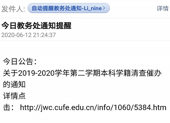